# Beginning with R (Rstudio)

14/02/2023

# What is R?

R is an environment that facilitates data handling and storage with a range of programming options allowing compatibility with other languages (e.g. python, css, C/C++).

The set of codes and functions to execute the data handling task come with multiple packages. There are 25 inbuilt packages that facilitate powerful analysis and handling of variety of objects.

## Installation of R

You can install R using this link https://cloud.r-project.org according to your operating system.

It provides with a ‘>’ prompt on the interface (terminal) where you can input your commands.

## Understanding simple input

Typing A<-1 and press enter on the > prompt in R will do followings. 1 is assigned to A. Here, A is the name of storage (called object) having a numeric value 1. Everything in R is an object. The assignment operator (->) ‘<’ and ‘-’ sign occur at the same time without space. Also, writing A<-1 is same as 1->A. So you can choose your style of writing the codes. One can also use ‘=’ in place of ‘<-’. I prefer using assignment operator in place of equal sign because equal signs are used as a logical expressions in comparing values, so it is better to avoid confusion and keep their distinct use.

Lets check how A appears in R. Type A and press enter that will give you following.

```r
A<-1
A
```

```
## [1] 1
```

This tells us that there is one element in A having value 1. Likewise, you can assign more values to an object in R.

Let us do simple calculations and understand the process slowly.

```r
A<-1
A
```

```
## [1] 1
```

```r
B<-2
B
```

```
## [1] 2
```

```r
A+B
```

```
## [1] 3
```

```r
C<-A+B
C
```

```
## [1] 3
```

Lets try storing words.

```r
#See if A<-hi works?
#Try this
A<-"hi"
A
```

```
## [1] "hi"
```

```r
B<-"bye"
B
```

```
## [1] "bye"
```

Likewise, lets import a file

```r
village<-read.csv(file="/Users/muditsingh/Desktop/Class/VillagedataUP.csv",header=T)
```

Do you want your storage and commands side by side. Not enjoying the non-GUI interface with limited options?

That is why RStudio is popular among people working with R.

## Installing RStudio

The Rstudio link can guide you through the installation of R and an updated version of Rstudio Desktop using the following link

https://www.rstudio.com/products/rstudio/download/#download

## Customize your view

You can choose how your Rstudio interface will look like by exploring this page https://support.rstudio.com/hc/en-us/articles/200549016-Customizing-the-RStudio-IDE

## Things to know before coding

R is a case sensitive expression language. It recognizes almost all the alphanumeric symbols depending up on the country of use. There are some essentials that everyone should know.

### Where am I working?

```r
getwd() # know your current working directory
```

```
## [1] "/Users/muditsingh/Desktop/Class/learnR"
```

```r
setwd("/Users/muditsingh/Desktop/Class/learnR") # know your current working directory
```

### Objects

The entities that R understands and uses to perform its operations are called *objects*. The objects can be a letter or combination of letters, storage, matrices, a file, list of files, numbers and so on. R performs its analysis based on the object type. So, it is important to understand how R classifies them. It treats the objects as *mode* and *length*.

### Classes of objects

- Character: anything inside double inverted commas (““).

```r
A<-"hi!"
A
```

```
## [1] "hi!"
```

```r
mode(A)
```

```
## [1] "character"
```

```r
class(A)
```

```
## [1] "character"
```

```r
length(A)
```

```
## [1] 1
```

How mode and class differ?

mode is intrinsic to object and class is a term for technical segregation of the object types. For the simplicity, lets stick to class and mode as an specific object property.

- Numeric: All the numbers from negative to positive.

```r
A<-5
A
```

```
## [1] 5
```

```r
B<--4
B
```

```
## [1] -4
```

- Factor: These are similar to categorical variables. E.g. Gender with two categories Male and Female will be a *factor* variable with two *levels* having “Male” and “Female” *labels*.

```r
A<-c("Name","Gender","Place")
class(A)
```

```
## [1] "character"
```

```r
B<-factor(A)#converting to factor with levels
B
```

```
## [1] Name   Gender Place
## Levels: Gender Name Place
```

```r
class(B)
```

```
## [1] "factor"
```

```r
length(B)
```

```
## [1] 3
```

- Logical: Comparing values as shown in some examples below. x>y #x is greater than y y<x #y is less than x x!=y #x is not equal to y

```r
A<-1
B<-2
A<B#compare A and B
```

```
## [1] TRUE
```

Why # sign? In R, we use # to insert comments/notes in the coding line.

Other than the four types of classification there are other types such as list, matrix, complex. At the moment, we begin with these for simplicity.

### Some operations for practice

```r
A<-c(10,12)
A
```

```
## [1] 10 12
```

The object ‘A’ looks like [1] 10 12

Now, it tells us that there are two elements. Lets understand storage pattern of the object A while assigning more elements to an object.

```r
A<-c(1,2,3,5,7,9)
A
```

```
## [1] 1 2 3 5 7 9
```

A[2] indicates the Second element in A1

A[1:5] lists first to fifth elements stored in A1

Similarly, lets try storing words.

```r
Boy<-"hi!"
Boy
```

```
## [1] "hi!"
```

```r
Girl<-"I want to learn R"
Girl
```

```
## [1] "I want to learn R"
```

We can practice assigning multiple numeric values and character (e.g. names) to different objects and check the outputs.

Lets practice some simple calculations.

```r
A<-2
B<-4
C<-A+B#addition
D<-A/B#division
E<-A-B#subtraction
F<-A*B#multiplication
G<-c(C,D,E,F)
G
```

```
## [1]  6.0  0.5 -2.0  8.0
```

```r
#Lets try with two elements in each
A<-c(2,4)
B<-c(4,6)
C<-A+B#addition
D<-A/B#division
E<-A-B#subtraction
F<-A*B#multiplication
H<-c(C,D,E,F)
H
```

```
## [1]  6.0000000 10.0000000  0.5000000  0.6666667 -2.0000000 -2.0000000  8.0000000
## [8] 24.0000000
```

### Using functions

```r
prod(1,3,5)#product (multiplication)
```

```
## [1] 15
```

```r
sum(1,2)#addition
```

```
## [1] 3
```

Can we join the two objects ‘A’ and ‘B’ in a meaningful way?

Lets try combining boy and girl statements from above example.

```r
statement<-paste(Boy,Girl)
statement
```

```
## [1] "hi! I want to learn R"
```

*What is ‘paste’?* It is a function that links together the objects. *What are functions?* A set of codes that gives the pre-defined operation on the object.One function for one task.

Lets try the following example.

```r
first10<-paste(1:10)
nth <- paste(1:7, c("st", "nd", "rd", rep("th", 4)))
paste(nth, collapse = ",")
```

```
## [1] "1 st,2 nd,3 rd,4 th,5 th,6 th,7 th"
```

```r
#Not looks like as expected? Try paste0
first10<-paste0(1:10)
nth <- paste0(1:7, c("st", "nd", "rd", rep("th", 4)))
paste(nth, collapse = ",")
```

```
## [1] "1st,2nd,3rd,4th,5th,6th,7th"
```

*So, how do paste and paste0 differ?*

```r
week<-c("Mon","Tue","Wed", "Thu", "Fri", "Sat", "Sun")
paste(week, nth, sep = ": ", collapse = "; ")
```

```
## [1] "Mon: 1st; Tue: 2nd; Wed: 3rd; Thu: 4th; Fri: 5th; Sat: 6th; Sun: 7th"
```

```r
#Using 'sep'
paste("1st", "2nd", "3rd", sep = ", ")
```

```
## [1] "1st, 2nd, 3rd"
```

*Quiz* 1. store your name to an object ‘name’

2. store your gender to the object ‘gender’
3. store your city/town/village name to an object ‘location’
4. store in an object(Hint: paste)
5. print the object displaying your name, gender and location
6. *Can we assign alphanumeric value to an object* (e.g. storing ‘AB12’ to some object)?*

## Handeling data files

We should have a place to store results and locate the place from where we can import data. Computer calls it directory.

### Importing file(s)

- Importing single file from your computer

```r
village<-read.csv(file="/Users/muditsingh/Desktop/Class/VillagedataUP.csv",header=T)#Alternatively, use file menu
```

- Downloading from the website

```r
download.file(url="https://dataverse.harvard.edu/api/access/datafile/4805891",
              destfile = "df.csv",cacheOK=TRUE)
webvillage<-read.csv("df.csv",header=T,sep="\t",stringsAsFactors = FALSE)

#Lets try another website sample
download.file(url="https://dataverse.harvard.edu/api/access/datafile/:persistentId?persistentId=doi:10.7910/DVN/6PAHVM/DZ6ADX",destfile = "df.csv",cacheOK=TRUE)

sample2<-read.csv("df.csv",header=T,sep="\t",stringsAsFactors = FALSE)
```

Notice options with the ‘download.file’ and ‘read.csv’ functions destfile:location where the downloaded file will be stored from the website cacheOK:Sometimes server stores the web data in cache that is not live.

*Question* Why do we set ‘factor’ mode to ‘false’ while downloading files?

### Importing multiple files from your computer

```r
villages<-list.files(path="/Users/muditsingh/Desktop/Class/learnR",pattern="*.csv")
myfiles = lapply(villages, read.delim)
file1<-myfiles[[3]]#we got our village file
```

## Explore your Data

```r
View(village)#Try using table icon on the right in Environment pane
head(village,n=5L)#Check with top five rows
tail(village,n=3L)#Check with last three rows
#More views
tail(village, c(6L, 2L))
tail(village, c(2L,5L))
#Locating your column, row and variable
income<-village$Income#Income variable
gender<-village$Gender#Gender variable
village[1,1]#First row, first column.
village[2,3]#second row, third column
village[,1]#All rows, first column
names(village)
colnames(village)
rownames(village)
#Rename your variable
names(village)[names(village)=='Block_Name']<-'Blocks'
rownames(village)[rownames(village)=='1']<-'firstrow'
#sorting
sort(village$Income,decreasing=TRUE)
```

Notice the [ ] symbol. [ ] tells that the object is a data frame. So, point to remember- we use small brackets () to apply functions and big brackets to [] denote a data frame (that we understand as a data file).

Want to try more user friendly English language way instead of using bracket symbols? Install “dplyr” package. The package is like a grammar of data wrangling. The package is highly helpful in variable selection, renaming and filtering data from your data file.

To do so, use the following code.

```r
#install.packages("dplyr")
```

Unlike other program applications, the functions (select, rename etc.) we want to use will not automatically become straight forward available for our use.

In order to use those functions, we first load the library of all the functions. This is usual way of using a package and associated function in R.

Lets call the functions of the package by using library.

```r
library(dplyr)
```

Lets try a few simple commands such as selecting a variable and renaming.

```r
library(dplyr)
#selecting income variable
Income<-select(village, Income)
#renaming Edu_highest variable
rename(village,education="Edu_highest")
```

You can explore more about the functions and package from the help tab.

### Summarizing your Data

```r
mean(village$Income)
```

```
## [1] 7901.724
```

```r
median(village$Income)
```

```
## [1] 6300
```

```r
Freq<-table(village$Gender)
#Not readable? Lets change it into a dataframe
freq_table<-data.frame(Freq)#notice data.frame function
names(freq_table)[names(freq_table) == 'Var1'] <- 'Gender'#Recall renaming
#Lets see two variable table
table(village$Land_own, village$Gender)
```

```
##
##                   Female Male
##   Marginal farmer     15   44
##   Small farmer         3   25
```

```r
freq_table2<-table(village$Land_own, village$Gender)
freq_table2<-data.frame(freq_table2)
names(freq_table2)[names(freq_table2) == 'Var1'] <- 'Land ownership'
names(freq_table2)[names(freq_table2) == 'Var2']<- 'Gender'
#Using Summary
summary(village$Income)
```

```
##    Min. 1st Qu.  Median    Mean 3rd Qu.    Max.
##       0    3500    6300    7902    9900   55000
```

```r
summary(village$Age)
```

```
##    Min. 1st Qu.  Median    Mean 3rd Qu.    Max.
##   30.00   41.00   55.00   53.09   62.00   85.00
```

```r
summary(village$HH_size)
```

```
##    Min. 1st Qu.  Median    Mean 3rd Qu.    Max.
##   2.000   4.000   6.000   6.241   7.000  21.000
```

```r
#Try summary with qualitative variable
summary(village$Gender)
```

```
##    Length     Class      Mode
##        87 character character
```

```r
#not expected result! Takeaway: summary works for quantitative variables.
```

### Visualizing your results

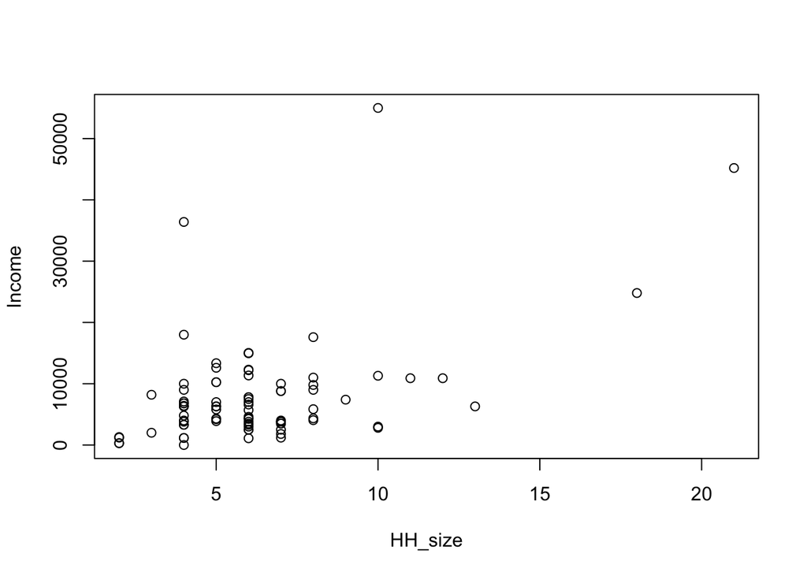

```r
HH_size<-village$HH_size
Income<-village$Income
plot(HH_size, Income)
```

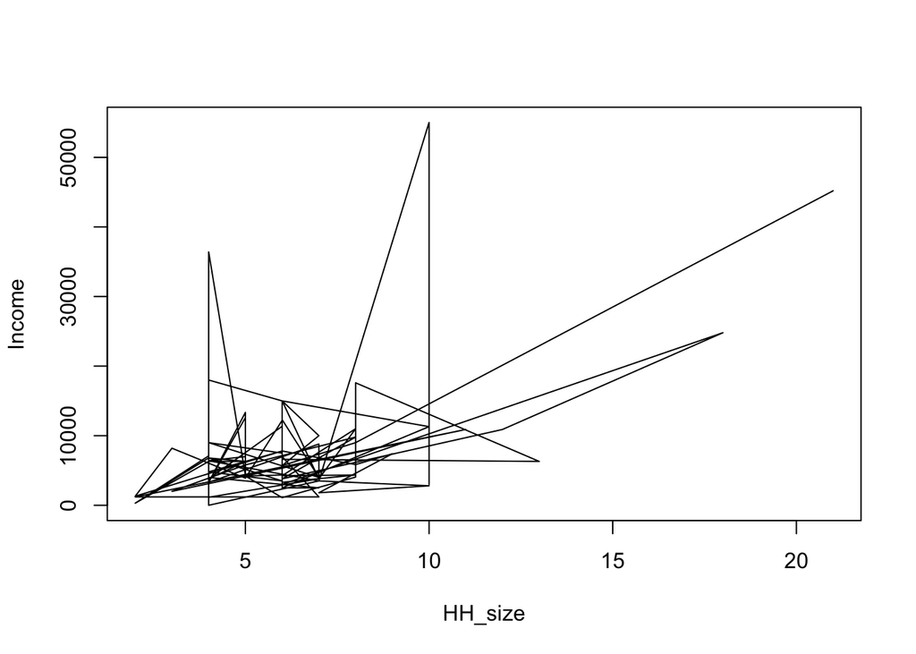

```r
#change data point type
plot(HH_size, Income, type="l")#does not make sense? try type="p"
```

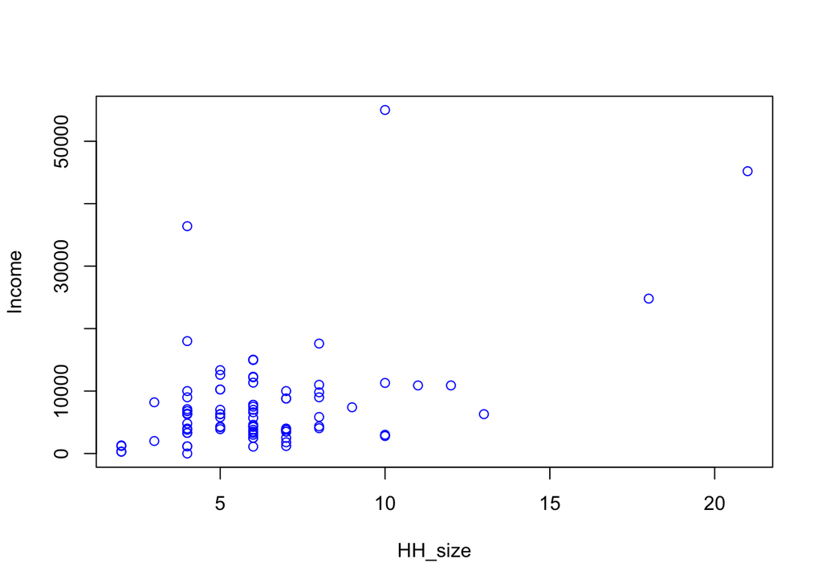

```r
#Add color
plot(HH_size, Income, type="p", col="blue")
```

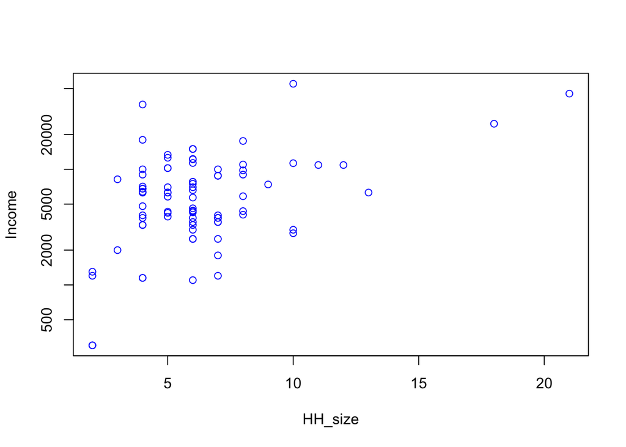

```r
#customize scale
plot(HH_size, Income, type="p", col="blue", log="y")
```

Explore more about “plot” in help search bar.

Lets try a bar plot with categorical variables

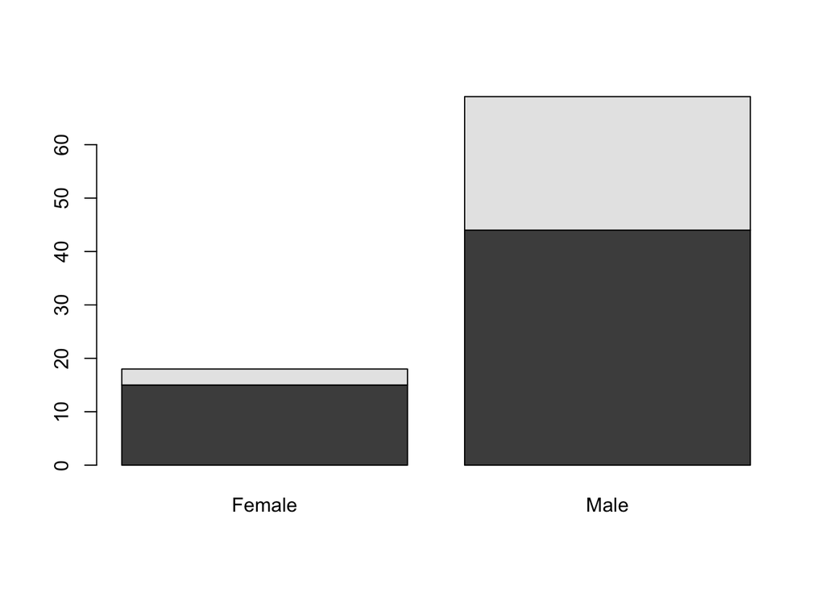

```r
barplot(table(village$Land_own, village$Gender))#by default it is stacked
```

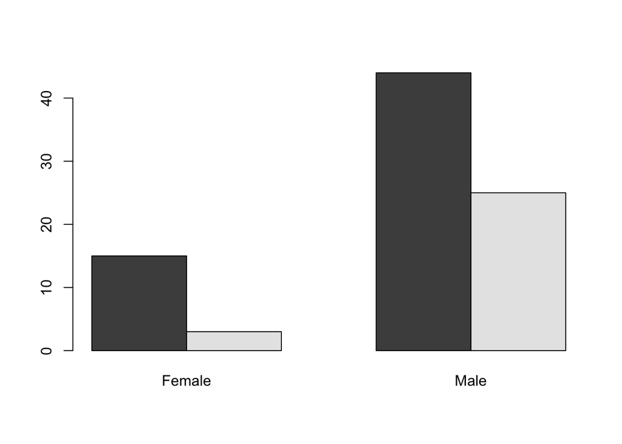

```r
#change the appearance
barplot(table(village$Land_own, village$Gender),beside=T)
```

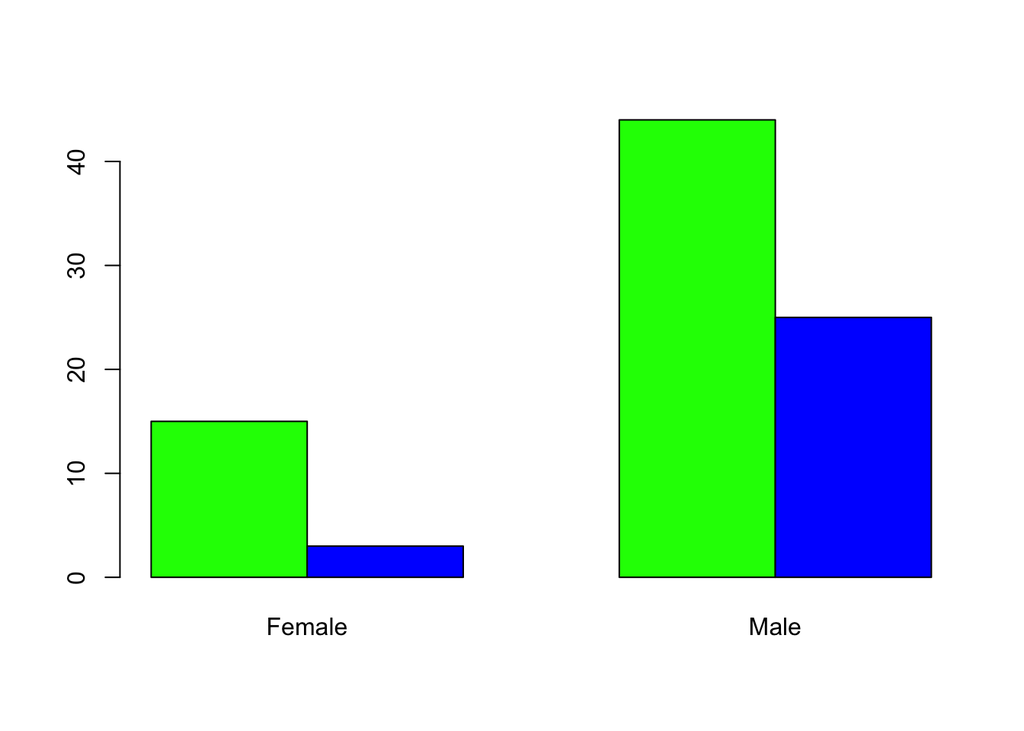

```r
#add colour
barplot(table(village$Land_own, village$Gender),beside=T,col=c("green","blue"))
```

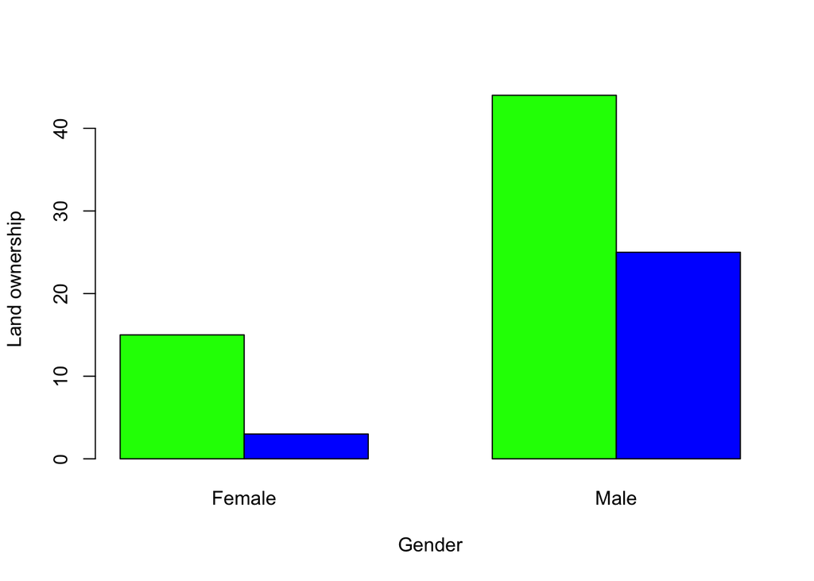

```r
#Adding labels
barplot(table(village$Land_own, village$Gender),beside=T,col=c("green","blue"),      ylab="Land ownership", xlab="Gender")
```

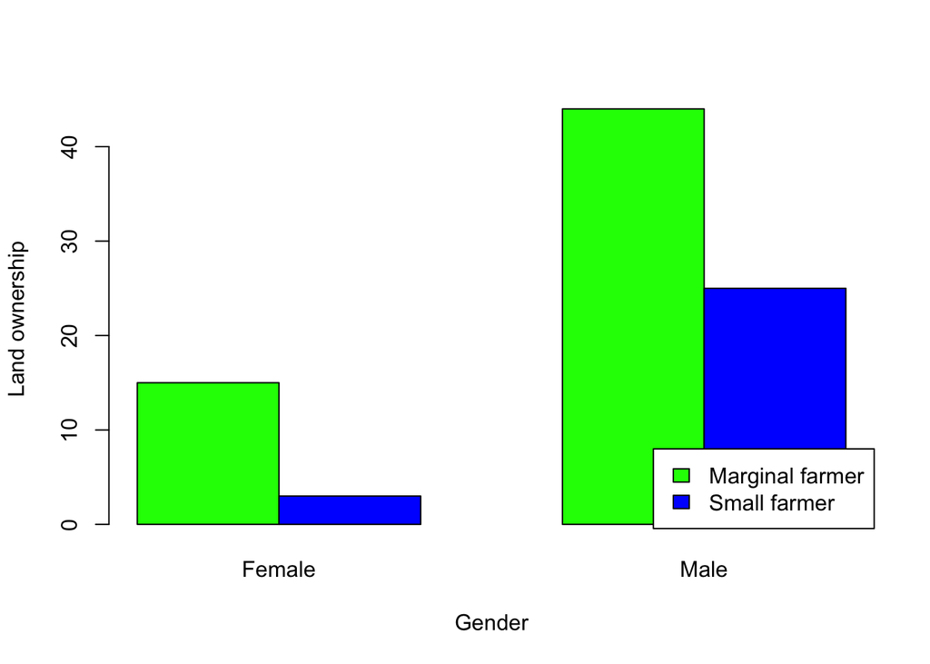

```r
#Adding legend
barplot(table(village$Land_own, village$Gender),beside=T,col=c("green","blue"),      ylab="Land ownership", xlab="Gender",legend.text = T,args.legend =list(x="bottomright"))
```

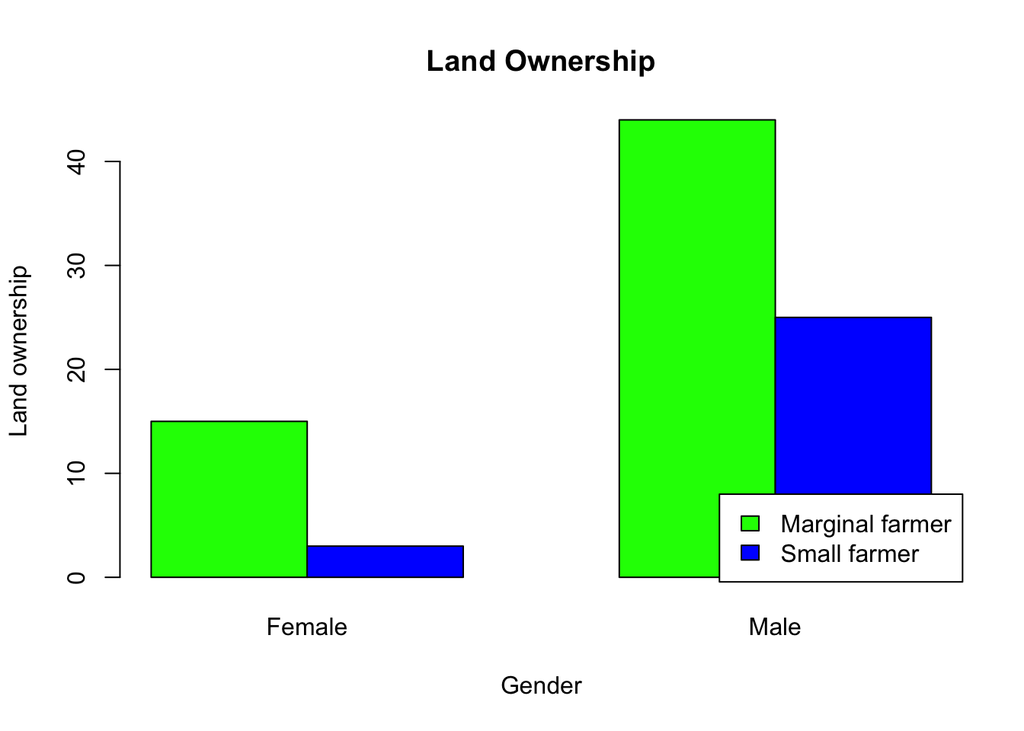

```r
#Add title
barplot(table(village$Land_own, village$Gender),beside=T,col=c("green","blue"),     ylab="Land ownership", xlab="Gender",legend.text = T,args.legend =list(x="bottomright"),main="Land Ownership")
```

You can do more visualization and customization with the package “ggplot2”. It is an improved version of “ggplot” package.

## Association and coorelation

### Association

From the above data we can test following hypothesis

$$H_0\ Land\ ownership\ and\ gender\ are\
independent$$
In other words, no relationship exists between ownership and gender.

```r
chisq.test(village$Land_own, village$Gender)
```

```
##
##  Pearson's Chi-squared test with Yates' continuity correction
##
## data:  village$Land_own and village$Gender
## X-squared = 1.6876, df = 1, p-value = 0.1939
```

```r
#storing and printing the result
asso<-chisq.test(village$Land_own, village$Gender)
```

Notice the object type we just used to store the chi-square result. It is a list.

```r
#Lets explore the items in the list
asso$observed
```

```
##                  village$Gender
## village$Land_own  Female Male
##   Marginal farmer     15   44
##   Small farmer         3   25
```

```r
asso$expected
```

```
##                  village$Gender
## village$Land_own     Female    Male
##   Marginal farmer 12.206897 46.7931
##   Small farmer     5.793103 22.2069
```

```r
asso$p.value
```

```
## [1] 0.1939156
```

We want to extract the relevant observed and expected value tables from the object and store in a meaningful presentable way.

```r
#extract the observed values
chi_obs<-asso$observed
chi_obs<-data.frame(chi_obs)
write.csv(chi_obs, "chi_result.csv")
#extract the expected values
chi_exp<-asso$expected
chi_exp<-data.frame(chi_exp)
```

### Correlation

$$H_0\ Education\ and\ Income\ are\ not\
correlated$$

```r
Education<-village$Edu_highest
Income<-village$Income

cor.test(Education, Income)
```

```
##
##  Pearson's product-moment correlation
##
## data:  Education and Income
## t = 2.3767, df = 85, p-value = 0.01972
## alternative hypothesis: true correlation is not equal to 0
## 95 percent confidence interval:
##  0.04113943 0.43727927
## sample estimates:
##       cor
## 0.2496245
```

Is our result reliable? Lets check the assumptions of pearson correlation test and learn how distribution matters.

The test says it follows a t distribution with length(x)-2 degrees of freedom if the samples follow independent normal distributions.

check our distribution hist(village$Income)

Lets normalize the distribution of income by taking log

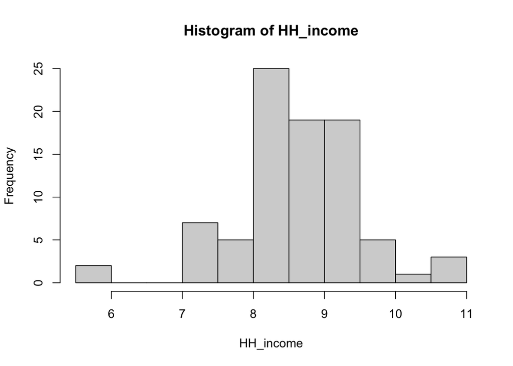

```r
HH_income<-log(village$Income)
hist(HH_income)
```

```r
cor.test(Education, HH_income)#Not expected result
```

```
##
##  Pearson's product-moment correlation
##
## data:  Education and HH_income
## t = NaN, df = 85, p-value = NA
## alternative hypothesis: true correlation is not equal to 0
## 95 percent confidence interval:
##  NaN NaN
## sample estimates:
## cor
## NaN
```

We get NaN error messages due to presence of infinte value in our data. A quick look at HH_income tells us “-Inf” value in 24th row of income variable.

Since, we applied log to income and a respondent reported the income as zero, the log transformation yielded the result as infinite. Hence, we got the error.

Lets eliminate the Inf value either by dropping it from analysis or by assigning the original zero value as “1” so that log of 1 will ultimately result to zero in our final correlation analysis.

```r
village$Income[village$Income==0]<-1
HH_income<-log(village$Income)
#hist(HH_income)
cor<-cor.test(Education, HH_income)
#convert the list object to data frame (table)
cor_table<-data.frame(cor$statistic)
cor_table$p_value<-cor$p.value
cor_table$estimate<-cor$estimate
#we do not want 't' in row name while exporting the table
write.csv(cor_table, "cor_result.csv", row.names=FALSE)
```

To know more about R, please refer to https://cran.r-project.org/doc/manuals/r-release/R-intro.html